# Analysis of Reasons for Claim Dismissal

Code for Charlottesville

10/15/2019

In this document, we address the following goal:

### Goal: Let’s understand the REASONS why wage theft claims are rejected.

Deliverables:

- Categorize the many reasons in the “other” field
- A good-looking table of the frequency of reasons, after the “other” reasons have been categorized
- Another table showing (1) how many claims DOLI has rejected on that basis during the last five years and (2) the total amount of stolen wages that DOLI refused to pursue on that basis.

We worked to categorize all of the reasons typed into the “other” fields for in valid and undetermined claims. Our spreadsheet with this work is here: https://docs.google.com/spreadsheets/d/1M6SJ08PV-oYjN6LbwtC_3C4XvPbVX5f8i9cIwk2WzfU/edit?usp=sharing

## Technical Data Cleaning Stuff

Please ignore the following code:

```r
library(tidyverse)
library(lubridate)
library(knitr)

lajc <- read_csv("lajc_wage_claim.csv")

lajc <- lajc %>%
  rename(claimID = `CLAIM NO`,
         employer = `EMPLOYER NAME`,
         employercity = `EMPLOYER CITY`,
         employerstate = ST,
         employerzip = ZIP,
         complainantcity = `COMPLAINANT CITY`,
         complainantrstate = ST_1,
         complainantrzip = ZIP_1,
         claim_amount = `CLAIM AMT`,
         case_open = `CASE OPEN/RE-OPEN`,
         valid = Valid,
         invalid = Invalid,
         verified_claim = `VERIFIED CLAIM AMT`,
         case_close = `CASE CLOSE/RECLOSE DATE`,
         first_response = `1st Response Investigation`,
         formal_investigate = `Formal Investigation`,
         wage_order = `Wage Order`,
         total_rec = `TOT AMT`,
         wage_rec = `WAGE AMT`) %>%
  dplyr::select(claimID, starts_with("employer"), gender, hispanic, asian, claim_amount, case_open, valid,
         invalid, verified_claim, case_close, first_response, formal_investigate, wage_order, total_rec,
         wage_rec, -starts_with("EMPLOYER ")) %>%
  mutate(gender = factor(gender),
         claim_amount = substring(claim_amount, 2),
         verified_claim = substring(verified_claim, 2),
         total_rec = substring(total_rec, 2),
         wage_rec = substring(wage_rec, 2),
         claim_amount = str_remove(claim_amount, ","),
         verified_claim = str_remove(verified_claim, ","),
         total_rec = str_remove(total_rec, ","),
         wage_rec = str_remove(wage_rec, ","),
         claim_amount = as.numeric(claim_amount),
         verified_claim = as.numeric(verified_claim),
         total_rec = as.numeric(total_rec),
         wage_rec = as.numeric(wage_rec),
         case_open = dmy(case_open),
         case_close = dmy(case_close),
         duration = case_close - case_open,
         valid = (valid == "X"),
         invalid = (invalid == "X"),
         first_response = (first_response == "X"),
         formal_investigate = (formal_investigate == "X"),
         wage_order = (wage_order == "X"),
         valid = ifelse(is.na(valid), FALSE, valid),
         invalid = ifelse(is.na(invalid), FALSE, invalid),
         first_response = ifelse(is.na(first_response), FALSE, first_response),
         wage_order = ifelse(is.na(wage_order), FALSE, wage_order),
         formal_investigate = ifelse(is.na(formal_investigate), FALSE, formal_investigate))

write_csv(lajc, path="lajc_clean.csv")

reasons <- read_csv("Reasons Unmapped - Category Counts.csv", col_names = c("claimID", "reason"))
lajc <- full_join(lajc, reasons)

lajc_invalid <- filter(lajc, invalid)
lajc_undetermined <- filter(lajc, !invalid & !is.na(reason))
```

## The reasons cited by DOLI

Here are reasons cited by DOLI for determining a claim to be invalid:

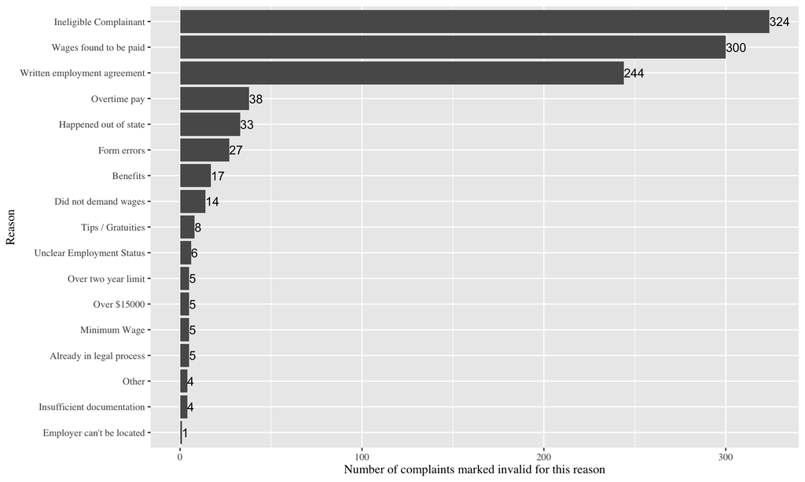

```r
lajc_invalid_bar <- lajc_invalid %>%
  group_by(reason) %>%
  summarize(count = n()) %>%
  na.omit()
g <- ggplot(lajc_invalid_bar, aes(x = reorder(reason, count), y=count)) +
  geom_bar(stat="identity") +
  geom_text(aes(label=count), hjust=0) +
  coord_flip() +
  xlab("Reason") +
  ylab("Number of complaints marked invalid for this reason") +
  theme(text=element_text(family="serif"))
g
```

Here are reasons cited by DOLI for determining a claim to be undetermined:

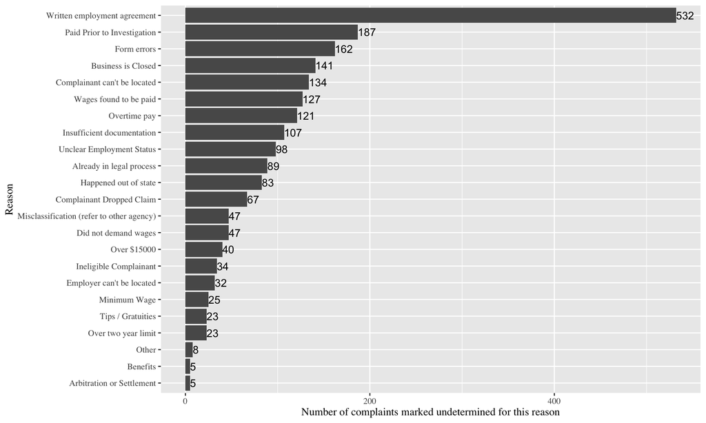

```r
lajc_undetermined_bar <- lajc_undetermined %>%
  group_by(reason) %>%
  summarize(count = n()) %>%
  na.omit()
g <- ggplot(lajc_undetermined_bar, aes(x = reorder(reason, count), y=count)) +
  geom_bar(stat="identity") +
  geom_text(aes(label=count), hjust=0) +
  coord_flip() +
  xlab("Reason") +
  ylab("Number of complaints marked undetermined for this reason") +
  theme(text=element_text(family="serif"))
g
```

## Amount claimed by reason

Here are the average and total amounts claimed by reason for finding a claim invalid:

```r
lajc_invalid_claimed <- lajc_invalid %>%
  group_by(reason) %>%
  summarize(`Frequency of reason` = n(),
            `Total wages claimed` = sum(claim_amount),
            `Average wages claimed` = mean(claim_amount)) %>%
  na.omit() %>%
  rename(Reason = reason) %>%
  arrange(-`Total wages claimed`)
kable(lajc_invalid_claimed)
```

| Reason | Frequency of reason | Total wages claimed | Average wages claimed |
| --- | --- | --- | --- |
| Over $15000 | 5 | 1127345.76 | 225469.152 |
| Happened out of state | 33 | 987723.89 | 29931.027 |
| Ineligible Complainant | 324 | 607416.57 | 1874.743 |
| Written employment agreement | 244 | 500212.77 | 2050.052 |
| Wages found to be paid | 300 | 417005.20 | 1390.017 |
| Over two year limit | 5 | 110511.53 | 22102.306 |
| Overtime pay | 38 | 75080.31 | 1975.798 |
| Benefits | 17 | 36111.78 | 2124.222 |
| Form errors | 27 | 31249.46 | 1157.387 |
| Did not demand wages | 14 | 26165.84 | 1868.989 |
| Unclear Employment Status | 6 | 16481.35 | 2746.892 |
| Already in legal process | 5 | 11702.75 | 2340.550 |
| Tips / Gratuities | 8 | 6932.32 | 866.540 |
| Other | 4 | 6565.53 | 1641.382 |
| Minimum Wage | 5 | 3301.42 | 660.284 |
| Insufficient documentation | 4 | 2281.04 | 570.260 |
| Employer can’t be located | 1 | 700.00 | 700.000 |

Here are the average and total amounts claimed by reason for finding a claim undetermined:

```r
lajc_undetermined_claimed <- lajc_undetermined %>%
  group_by(reason) %>%
  summarize(`Frequency of reason` = n(),
            `Total wages claimed` = sum(claim_amount),
            `Average wages claimed` = mean(claim_amount)) %>%
  na.omit() %>%
  rename(Reason = reason) %>%
  arrange(-`Total wages claimed`)
kable(lajc_undetermined_claimed)
```

| Reason | Frequency of reason | Total wages claimed | Average wages claimed |
| --- | --- | --- | --- |
| Written employment agreement | 532 | 1605784.96 | 3018.3928 |
| Over $15000 | 40 | 1446849.87 | 36171.2467 |
| Already in legal process | 89 | 536163.47 | 6024.3087 |
| Unclear Employment Status | 98 | 370072.36 | 3776.2486 |
| Business is Closed | 141 | 319269.03 | 2264.3194 |
| Overtime pay | 121 | 227812.10 | 1882.7446 |
| Happened out of state | 83 | 203445.76 | 2451.1537 |
| Insufficient documentation | 107 | 187627.66 | 1753.5295 |
| Paid Prior to Investigation | 187 | 185249.52 | 990.6391 |
| Over two year limit | 23 | 176312.27 | 7665.7509 |
| Complainant Dropped Claim | 67 | 166472.80 | 2484.6687 |
| Complainant can’t be located | 134 | 160511.56 | 1197.8475 |
| Ineligible Complainant | 34 | 155530.78 | 4574.4347 |
| Wages found to be paid | 127 | 127106.51 | 1000.8387 |
| Form errors | 162 | 100297.18 | 619.1184 |
| Minimum Wage | 25 | 92662.99 | 3706.5196 |
| Did not demand wages | 47 | 74605.93 | 1587.3602 |
| Misclassification (refer to other agency) | 47 | 49838.38 | 1060.3911 |
| Employer can’t be located | 32 | 36943.61 | 1154.4878 |
| Tips / Gratuities | 23 | 29419.63 | 1279.1143 |
| Other | 8 | 13671.72 | 1708.9650 |
| Benefits | 5 | 6990.54 | 1398.1080 |
| Arbitration or Settlement | 5 | 2143.90 | 428.7800 |

## Duration of cases by reason

```r
lajc_invalid_claimed <- lajc_invalid %>%
  group_by(reason) %>%
  summarize(`Frequency of reason` = n(),
            `Average duration` = mean(duration)) %>%
  na.omit() %>%
  rename(Reason = reason) %>%
  arrange(-`Average duration`)
kable(lajc_invalid_claimed)
```

| Reason | Frequency of reason | Average duration |
| --- | --- | --- |
| Other | 4 | 36.000000 days |
| Wages found to be paid | 300 | 22.730000 days |
| Insufficient documentation | 4 | 18.750000 days |
| Employer can’t be located | 1 | 17.000000 days |
| Already in legal process | 5 | 8.600000 days |
| Benefits | 17 | 8.411765 days |
| Unclear Employment Status | 6 | 6.333333 days |
| Ineligible Complainant | 324 | 4.583333 days |
| Written employment agreement | 244 | 3.913934 days |
| Over two year limit | 5 | 3.600000 days |
| Overtime pay | 38 | 1.894737 days |
| Minimum Wage | 5 | 1.800000 days |
| Tips / Gratuities | 8 | 1.375000 days |
| Happened out of state | 33 | 1.151515 days |
| Form errors | 27 | 1.000000 days |
| Did not demand wages | 14 | 0.000000 days |
| Over $15000 | 5 | 0.000000 days |

```r
lajc_undetermined_claimed <- lajc_undetermined %>%
  group_by(reason) %>%
  summarize(`Frequency of reason` = n(),
            `Average duration` = mean(duration)) %>%
  na.omit() %>%
  rename(Reason = reason) %>%
  arrange(-`Average duration`)
kable(lajc_undetermined_claimed)
```

| Reason | Frequency of reason | Average duration |
| --- | --- | --- |
| Misclassification (refer to other agency) | 47 | 53.7446809 days |
| Insufficient documentation | 107 | 35.6728972 days |
| Employer can’t be located | 32 | 34.8437500 days |
| Other | 8 | 31.2500000 days |
| Wages found to be paid | 127 | 28.7322835 days |
| Arbitration or Settlement | 5 | 24.8000000 days |
| Complainant can’t be located | 134 | 18.1641791 days |
| Unclear Employment Status | 98 | 15.0102041 days |
| Complainant Dropped Claim | 67 | 14.9402985 days |
| Already in legal process | 89 | 12.4494382 days |
| Business is Closed | 141 | 12.0851064 days |
| Paid Prior to Investigation | 187 | 6.1443850 days |
| Tips / Gratuities | 23 | 5.5652174 days |
| Overtime pay | 121 | 4.1900826 days |
| Ineligible Complainant | 34 | 3.7647059 days |
| Minimum Wage | 25 | 3.1600000 days |
| Happened out of state | 83 | 2.3012048 days |
| Written employment agreement | 532 | 2.0883459 days |
| Form errors | 162 | 2.0555556 days |
| Over $15000 | 40 | 0.5250000 days |
| Benefits | 5 | 0.4000000 days |
| Did not demand wages | 47 | 0.1489362 days |
| Over two year limit | 23 | 0.0869565 days |